# DS養成講座 Jリーグ観客動員数を予測せよ！

Shinji KAWASOE

Data : 2017-12-02

# 1 概要

コンペの内容  
https://deepanalytics.jp/compe/27

本コンテストでは、2012年～2014年シーズン前半までのデータを使って、  
「2014年後半戦J1,J2全試合の観客動員数を予測するモデル」  
を作成していただきます。

```r
outputfilename <- "submit_20171202_1_lm.csv"
```

# 2 取り組み内容

## 2.1 ポイントとその履歴

2017.12.02

結果 3,537.27864

- ランキングにて得失点を考慮

2017.11.28

結果 3,541.44095

- ピタゴラス勝率の勝点、失点の算出ミスを修正

2017.11.27 r2

結果 3,541.89157

- nearとheatを削除

2017.11.27

結果 3,582.94275

- ピタゴラス勝率を追加

2017.11.26

結果 3,581.42363

- 点数が近いチームは盛り上がる？near変数の作成
- 後半の下位争いは盛り上がる？heat変数の作成

2017.11.24 r2

結果 3,541.17803

- スタジアム別名の統合
  - 長崎県立総合運動公園陸上競技場 -> 長崎市総合運動公園かきどまり陸上競技場
- チーム名改名を統合
  - ザスパクサツ群馬 -> ザスパ草津

2017.11.24

結果 3,541.71704

- home, awayを分けていたレコードをマージする。
- stargeを分けない。
- HoledOutを期間からランダムに変更した。

2017.11.22

結果 3,588.19272

- stageでデータとモデルを分ける。

2017.11.21

結果 3,581.93207

- tv局数、節、ホームチーム、アウェイチーム、開始時刻、土日祝、雨のパラメータを追加した。

2017.11.20

結果 6,048.90214

- 追加データを加える。
- 勝点と前節ランキングを算出する。

2017.11.10

結果 6,071.35336

- HoldOutを2012-2013年を構築データとし、2014年を検証データで行なう。
- R Markdownを作成する。

## 2.2 モデル作成用のカラム

```r
## 使用ライブラリ
library(tidyverse)
library(knitr)

param <- c("capa", "pre_rank.home", "pre_rank.away", "media", "section", "home_team", "away_team","hour","week","rain", "pre_win_rate.home", "pre_win_rate.away")
explain <- c("スタジアムの収容人数", "前節のランキング(home)","前節のランキング(away)", "tv局数", "節", "ホームチーム", "アウェイチーム", "開始時刻", "1(土日祝)、0(平日)", "1(雨)、0(雨以外)","ピタゴラス勝率(home)","ピタゴラス勝率(away)")
cols <- data.frame(Parameter=param, Explain=explain)

kable(cols)
```

| Parameter | Explain |
| --- | --- |
| capa | スタジアムの収容人数 |
| pre_rank.home | 前節のランキング(home) |
| pre_rank.away | 前節のランキング(away) |
| media | tv局数 |
| section | 節 |
| home_team | ホームチーム |
| away_team | アウェイチーム |
| hour | 開始時刻 |
| week | 1(土日祝)、0(平日) |
| rain | 1(雨)、0(雨以外) |
| pre_win_rate.home | ピタゴラス勝率(home) |
| pre_win_rate.away | ピタゴラス勝率(away) |

# 3 データ加工

```r
## データ読込(結合したデータ)
train<-read.csv("../data/train_new.csv", #読込ファイル
                header=TRUE, #読込データのヘッダー有無
                stringsAsFactors=FALSE #文字列の読込時の型指定(character)
)
test<-read.csv("../data/test_new.csv",
               header=TRUE,
               stringsAsFactors=FALSE)
```

## 3.1 データ加工を全データに実施するため、trainとtestを結合する。

```r
test$y <- NA
combi <- rbind(train,test)

## 今は使わないカラムを減らして、少し見やすくする。後で使うかも。
combi <- combi %>%
    dplyr::select(-(home_01:home_11),-(away_01:away_11))
```

## 3.2 開催節を分割する。

時系列データとして扱い易いように変更する。  
開催節(match)を節(section)と連番(seq)に分ける。

```r
## 節を加工
combi <- combi %>%
    dplyr::mutate(match = purrr::map(match, stringi::stri_trans_nfkc)) %>%
    dplyr::mutate(match = str_replace_all(match, pattern = "[第日]", replacement = "")) %>%
    tidyr::separate(match, into = c('section','seq'), sep="節") %>%
    dplyr::mutate(section = as.numeric(section) ,
                  seq = as.numeric(seq))
```

## 3.3 勝点とランキングを考える。

### 3.3.1 勝点を算出する。

- 勝点は各節でTeam単位に出力されるため、home, awayの両方を計算する必要がある。
- 自分と相手のscoreを比較して、勝点(3,1,0)を算出する。

```r
## home, awayでレコードを分ける
combi_split <- combi %>%
    tidyr::gather(`home`,`away`, key="type", value="team") %>%
    dplyr::mutate(my_score = if_else(type=="home", home_score, away_score),
                  opponent_score = if_else(type=="home", away_score, home_score))

## 勝点の算出
combi_split <- combi_split %>%
    dplyr::mutate(victory_point = 0,
                  victory_point = if_else(my_score > opponent_score, 3, victory_point),
                  victory_point = if_else(my_score == opponent_score, 1, victory_point))
```

### 3.3.2 得失点を算出する。

- チームごと(group_by)に、自分と相手のscoreを減算して、その結果を累積(Cumulative)する。
- 勝点の累積を算出する。

```r
## 得失点、勝点の累積を算出
combi_point <- combi_split %>%
    dplyr::group_by(year, team) %>%
    dplyr::arrange(year,section,seq) %>%
    dplyr::mutate(cum_vp = cumsum(victory_point)) %>%
    dplyr::mutate(cum_score = cumsum(my_score - opponent_score)) %>%
    dplyr::mutate(for_calc_rank = cum_vp * 1000 + cum_score) %>%
    dplyr::ungroup(.)
```

### 3.3.3 順位を算出する。

- 節で切りTeamの全ての勝点と得失点でrankingを取る。
- rank : 節単位のランキング
- desc_rank : 逆順でのランキング(下位が上位)
- pre_rank : 前節のランキング

```r
combi_rank <- combi_point %>%
    dplyr::group_by(year, section, stage) %>%
    dplyr::mutate(rank = min_rank(desc(for_calc_rank))) %>%
    dplyr::mutate(desc_rank = if_else(stage == "Ｊ１", 34 - rank, 42 - rank)) %>%
    dplyr::ungroup(.)

combi_pre_rank <- combi_rank %>%
    dplyr::group_by(year, team) %>%
    dplyr::mutate(pre_rank = lag(rank)) %>%
    dplyr::ungroup(.) %>%
    dplyr::mutate(pre_rank = ifelse(is.na(pre_rank),0, pre_rank)) %>%
    dplyr::mutate(pre_desc_rank = if_else(stage == "Ｊ１", 34 - pre_rank, 42 - pre_rank))

## pre_rankにNAが含まれている。
## 後述する分析結果より、pre_rankがyに対して負の相関あり？と考えて、0を投入する。

combi_pre_rank %>%
    dplyr::filter(team == "鹿島アントラーズ") %>%
    dplyr::select(team, cum_vp, cum_score, rank) %>%
    head(20)
```

```
## # A tibble: 20 x 4
##                team cum_vp cum_score  rank
##               <chr>  <dbl>     <int> <int>
##  1 鹿島アントラーズ      0        -1    13
##  2 鹿島アントラーズ      0        -2    16
##  3 鹿島アントラーズ      0        -4    18
##  4 鹿島アントラーズ      1        -4    18
##  5 鹿島アントラーズ      1        -6    17
##  6 鹿島アントラーズ      4        -5    16
##  7 鹿島アントラーズ      7        -4    15
##  8 鹿島アントラーズ     10         1    11
##  9 鹿島アントラーズ     10        -2    15
## 10 鹿島アントラーズ     11        -2    14
## 11 鹿島アントラーズ     11        -5    15
## 12 鹿島アントラーズ     14         2    14
## 13 鹿島アントラーズ     17         3    12
## 14 鹿島アントラーズ     17         2    13
## 15 鹿島アントラーズ     18         2    13
## 16 鹿島アントラーズ     19         2    13
## 17 鹿島アントラーズ     22         3    13
## 18 鹿島アントラーズ     25         4    11
## 19 鹿島アントラーズ     26         4    11
## 20 鹿島アントラーズ     26         2    12
```

```r
combi_pre_rank %>%
    dplyr::filter(year == 2013, section == 12, stage == "Ｊ１") %>%
    dplyr::arrange(desc(for_calc_rank)) %>%
    dplyr::select(cum_vp, cum_score, for_calc_rank, rank) %>%
    head(10)
```

```
## # A tibble: 10 x 4
##    cum_vp cum_score for_calc_rank  rank
##     <dbl>     <int>         <dbl> <int>
##  1     29        13         29013     1
##  2     24        11         24011     2
##  3     24        11         24011     2
##  4     22         3         22003     4
##  5     21        10         21010     5
##  6     20         6         20006     6
##  7     19         6         19006     7
##  8     17         1         17001     8
##  9     17        -3         16997     9
## 10     16         0         16000    10
```

### 3.3.4 ピタゴラス勝率を算出する

[ピタゴラス勝率](https://ja.wikipedia.org/wiki/%E3%83%94%E3%82%BF%E3%82%B4%E3%83%A9%E3%82%B9%E5%8B%9D%E7%8E%87) 得点と失点からチームの勝率を予測するセイバーメトリクスの計算式で、今回は勝率を求める問題ではな いので、この値をチームが勝っている雰囲気をファンが感じている割合と解釈してみる。

$$WIN\% = \frac{(Runs Scored)^2}{(Runs Scored)^2 + (Runs Allowed)^2}$$

- Runs Scored : 得点
- Runs Allowed : 失点

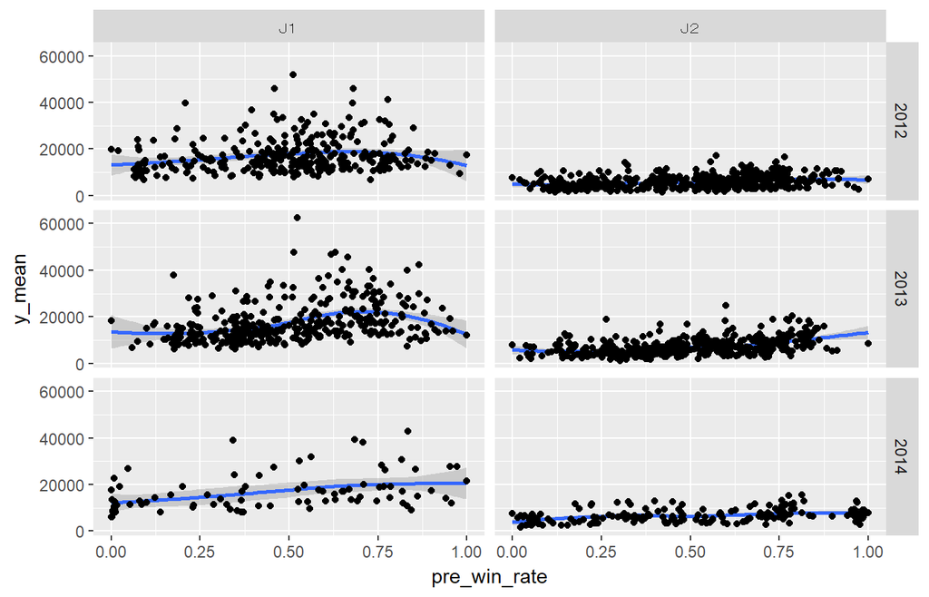

```r
### 勝点、失点の計算が点差で算出している箇所は誤り
## combi_pre_win_rate <- combi_pre_rank %>%
##     dplyr::group_by(year, team) %>%
##     dplyr::arrange(year,section,seq) %>%
##     dplyr::mutate(runs_scored = ifelse((my_score - opponent_score) > 0,(my_score - opponent_score), 0)) %>%
##     dplyr::mutate(runs_allowed = ifelse((my_score - opponent_score) > 0,0, (opponent_score - my_score))) %>%
##     dplyr::mutate(cum_runs_scored = cumsum(runs_scored)) %>%
##     dplyr::mutate(cum_runs_allowed = cumsum(runs_allowed)) %>%
##     dplyr::mutate(win_rate = ifelse(((cum_runs_scored)^2 + (cum_runs_allowed)^2) == 0,
##                                     0,
##                                     (cum_runs_scored)^2 / ((cum_runs_scored)^2 + (cum_runs_allowed)^2))) %>%
##     dplyr::mutate(pre_win_rate = lag(win_rate)) %>%
##     dplyr::mutate(pre_win_rate = ifelse(is.na(pre_win_rate), 0, pre_win_rate)) %>%
##     dplyr::ungroup(.)

combi_pre_win_rate <- combi_pre_rank %>%
    dplyr::group_by(year, team) %>%
    dplyr::arrange(year,section,seq) %>%
    dplyr::mutate(cum_runs_scored = cumsum(my_score)) %>%
    dplyr::mutate(cum_runs_allowed = cumsum(opponent_score)) %>%
    dplyr::mutate(win_rate = ifelse(((cum_runs_scored)^2 + (cum_runs_allowed)^2) == 0,
                                    0,
                                    (cum_runs_scored)^2 / ((cum_runs_scored)^2 + (cum_runs_allowed)^2))) %>%
    dplyr::mutate(pre_win_rate = lag(win_rate)) %>%
    dplyr::mutate(pre_win_rate = ifelse(is.na(pre_win_rate), 0, pre_win_rate)) %>%
    dplyr::ungroup(.)

combi_pre_win_rate %>%
    dplyr::group_by(year, stage, pre_win_rate) %>%
    dplyr::summarise(y_mean = mean(y)) %>%
    ggplot(mapping = aes(x = pre_win_rate, y = y_mean)) +
    geom_smooth() +
    geom_point() +
    facet_grid(year ~ stage)
```

若干、正の相関あり？  
ピタゴラス勝率が高いと観客動員数が下っているのは、勝ちが見えている試合は萎えるのかな？

### 3.3.5 home, away単位のレコードを試合単位に戻す

```r
## 試合単位にマージ
home_combi <- combi_pre_win_rate%>%
    dplyr::filter(type == "home") %>%
    dplyr::select(c(id, victory_point, cum_vp, cum_score, rank, desc_rank, pre_rank, pre_desc_rank, pre_win_rate))

away_combi <- combi_pre_win_rate%>%
    dplyr::filter(type == "away") %>%
    dplyr::select(c(id, victory_point, cum_vp, cum_score, rank, desc_rank, pre_rank, pre_desc_rank, pre_win_rate))

combi_ranking <- combi %>%
    dplyr::left_join(home_combi, by="id") %>%
    dplyr::rename(victory_point.home = victory_point,
                  cum_vp.home = cum_vp,
                  cum_score.home =cum_score,
                  rank.home = rank,
                  desc_rank.home = desc_rank,
                  pre_rank.home = pre_rank,
                  pre_desc_rank.home = pre_desc_rank,
                  pre_win_rate.home = pre_win_rate) %>%
    dplyr::left_join(away_combi, by="id") %>%
    dplyr::rename(victory_point.away = victory_point,
                  cum_vp.away = cum_vp,
                  cum_score.away =cum_score,
                  rank.away = rank,
                  desc_rank.away = desc_rank,
                  pre_rank.away = pre_rank,
                  pre_desc_rank.away = pre_desc_rank,
                  pre_win_rate.away = pre_win_rate)
```

## 3.4 その他の加工

### 3.4.1 テレビ局の数の導出

局数が増加すると動員数も増加している傾向が見られる。

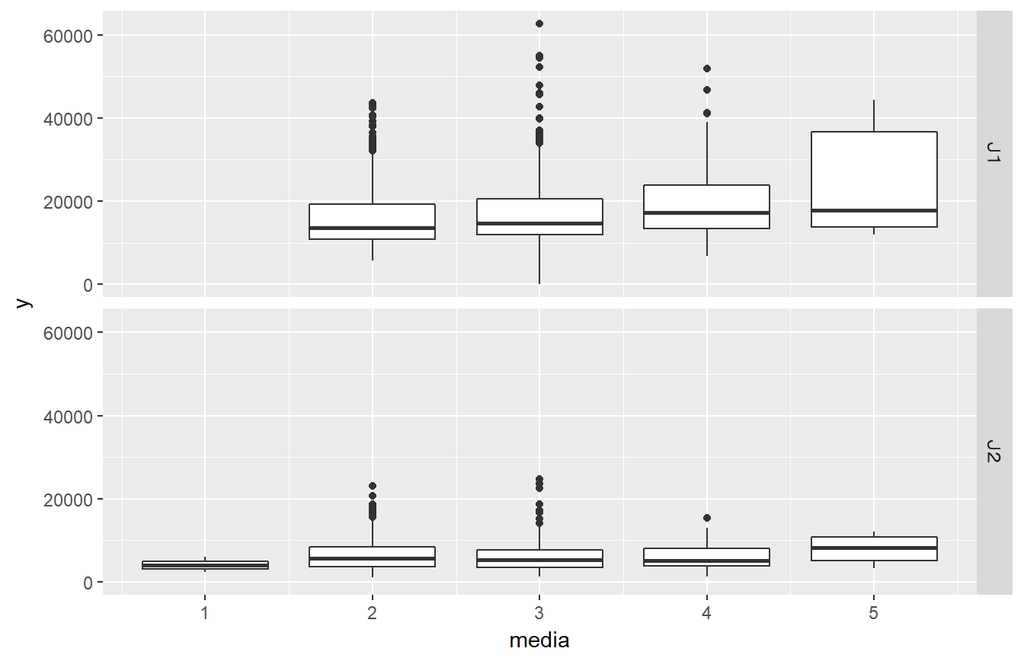

```r
combi_tv <- combi_ranking %>%
    dplyr::mutate(media = str_count(tv,"／") + 1)

combi_tv %>%
    ggplot(mapping = aes(x = media, y = y)) +
    geom_boxplot(aes(group = cut_width(media,1))) +
    facet_grid(stage ~ .)
```

### 3.4.2 開始時間

todo 翌日休みフラグ もう少し考えが必要

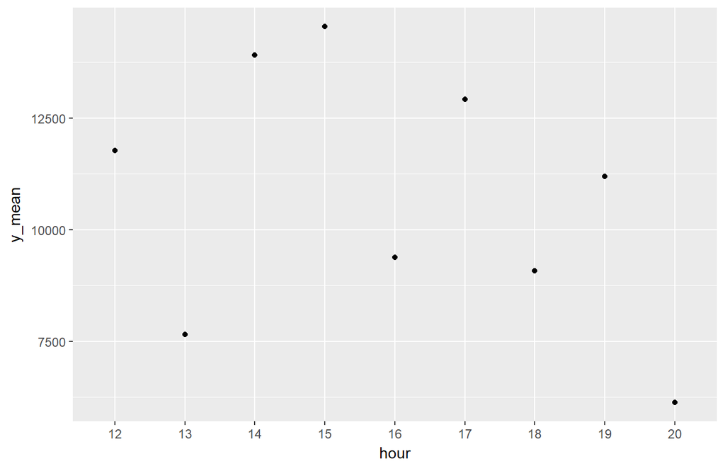

```r
combi_time <- combi_tv %>%
    dplyr::mutate(hour = str_sub(time, 1,2)) %>%
    dplyr::mutate(week = ifelse(str_detect(gameday,"[土日祝]"), 1, 0))

combi_time %>%
    dplyr::group_by(hour) %>%
    dplyr::summarise(y_mean = mean(y, na.rm=TRUE)) %>%
    dplyr::ungroup(.) %>%
    ggplot(mapping = aes(x = hour, y = y_mean)) + geom_point()
```

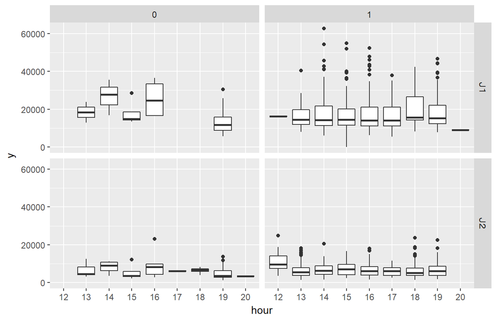

```r
ggplot(data = combi_time, mapping = aes(x = hour, y = y)) +
    geom_boxplot(aes(group = cut_width(hour,1))) +
    facet_grid(stage ~ week)
```

### 3.4.3 天候

雨の日が若干悪いがそれほど大差はない。

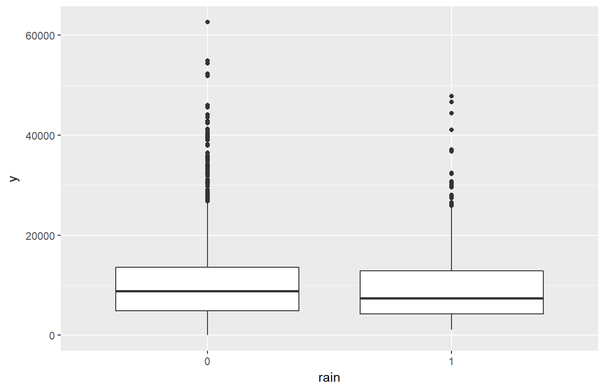

```r
combi_weather <- combi_time %>%
    dplyr::mutate(rain = as.factor(ifelse(str_detect(weather,"雨"), 1, 0)))

combi_weather %>%
    ggplot(mapping = aes(x = rain, y = y)) +
    geom_boxplot()
```

### 3.4.4 外れ値の削除

無観客試合の削除

```r
combi_y_0 <- combi_weather %>%
    dplyr::filter(is.na(y) | y != 0)
```

### 3.4.5 点数の近いチームの変数

点数の近いチーム(near)はyの説明変数とはならない。

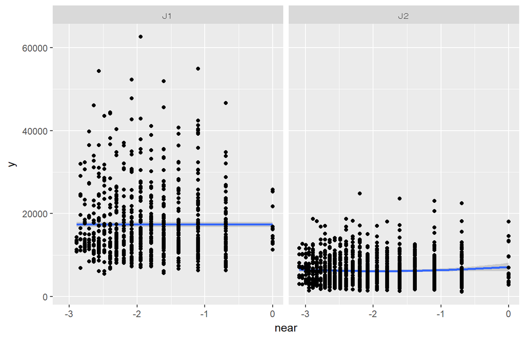

```r
combi_near <- combi_y_0 %>%
    dplyr::mutate(near = log(1/(abs(rank.home - rank.away) + 1)))

ggplot(data = combi_near, mapping = aes(x = near, y = y)) + geom_smooth() + geom_point() + facet_grid(. ~ stage)
```

### 3.4.6 節終盤で下位は盛り上るか？

傾向は見えない。現状、見方が悪いと思う。別の説明変数がよりyと相関する場合は、そちらに引きづられて、この変数の効果を確認できないのでは？

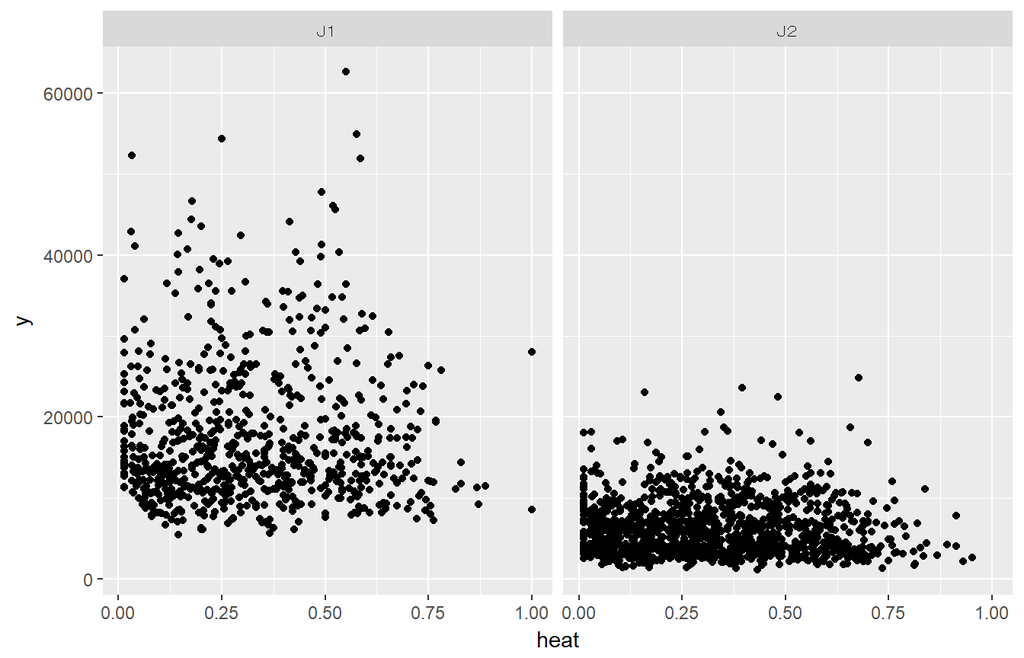

```r
combi_heat <- combi_near %>%
    dplyr::mutate(heat = section/(pre_desc_rank.home + pre_desc_rank.away + 1))

ggplot(data = combi_heat, mapping = aes(x = heat, y = y)) + geom_point() + facet_grid(. ~ stage)
```

```r
combi_mod <- combi_heat
```

## 3.5 trainとtestに分割する

```r
train <- combi_mod %>%
    dplyr::filter(!is.na(y))
test <- combi_mod %>%
    dplyr::filter(is.na(y))
```

# 4 Hold Outで検証

```r
## 構築データの割合
rate <- 0.7

## 構築データ数
num <- as.integer(nrow(train)*rate)

## 再現性のため乱数シードを固定
set.seed(17)

## sample(ベクトル, ランダムに取得する個数, 復元抽出の有無)
row<-sample(1:nrow(train), num, replace=FALSE)

## 構築データ
train_train <- train[row,]

## 検証データ
train_test <- train[-row,] %>%
    dplyr::filter(home_team != "カマタマーレ讃岐") %>%
    dplyr::filter(away_team != "カマタマーレ讃岐")
## カマタマーレ讃岐は2014からのチームなので、train_testから除外

###使用変数の作成
#変数選択(目的変数, 収容人数, 前節ランキング)
lm_train<-dplyr::select(train_train, y, param)
lm_test<-dplyr::select(train_test, param)

###重回帰分析
#family:目的変数の確率分布とリンク関数の設定(今回は正規分布と恒等写像)
lm<-glm(y ~ ., data=lm_train, family=gaussian(link="identity"))

### testに当てはめ
## type="response"でリンク関数を当てはめる前の値が返ってくる
pred<-predict(lm, lm_test, type="response")

## typeが無指定だとリンク関数を当てはめた値が返ってくる
## link="log"であれば, exp(pred)で予測値を返すことができる

## 結果出す前に、home,away分割を戻す
train_test$pred <- pred

result <- train_test %>%
    dplyr::group_by(id) %>%
    dplyr::summarise(
               y = mean(y),
               pred = mean(pred)
           )
## RMSEの計算
sqrt(mean((result$y - result$pred)^2))
```

```
## [1] 3219.497
```

# 5 OPT投稿データ作成

テストデータに追加ファイルを使用しているので、投稿対象の試合に絞る。

```r
## testデータにAddしたレコードを除去する。
sample <- read_csv("../motodata/sample_submit.csv", col_names=c("id","pred"))
nrow(sample)
```

```
## [1] 313
```

```r
nrow(test)
```

```
## [1] 351
```

```r
test <- test %>%
    dplyr::inner_join(sample %>% select(id), by="id")
nrow(test)
```

```
## [1] 313
```

```r
###使用変数の作成
#変数選択(目的変数, 収容人数, 前節ランキング)
lm_train<-dplyr::select(train, y, param)
lm_test<-dplyr::select(test, param)

###重回帰分析
#family:目的変数の確率分布とリンク関数の設定(今回は正規分布と恒等写像)
lm<-glm(y ~ ., data=lm_train, family=gaussian(link="identity"))

###testに当てはめ
#type="response"でリンク関数を当てはめる前の値が返ってくる
pred<-predict(lm, lm_test, type="response")

#typeが無指定だとリンク関数を当てはめた値が返ってくる
#link="log"であれば, exp(pred)で予測値を返すことができる

test$pred <- pred

###submit形式に整える
submit <- test %>%
    dplyr::select(c(id, pred))

str(submit)
```

```
## 'data.frame':    313 obs. of  2 variables:
##  $ id  : int  15822 15823 15824 15825 15827 15828 15829 15830 15831 15832 ...
##  $ pred: num  13123 18164 36000 12798 28280 ...
```

```r
###CSV出力(ヘッダーなし)
write.table(submit, file=paste("../submit/", outputfilename, sep=""),
            quote=FALSE, sep=",", row.names=FALSE, col.names=FALSE)
```

[output not shown]

```r
## 予測値が実測値より少い
kable(head(zan %>% dplyr::filter(diff>0), n=25))
```

| id | Res | y | pred | diff | stage | stadium | capa | gameday | section |
| --- | --- | --- | --- | --- | --- | --- | --- | --- | --- |
| 15127 | 33605.606 | 62632 | 29026.39 | 33605.606 | Ｊ１ | 日産スタジアム | 72327 | 11/30(土) | 33 |
| 15765 | 17885.958 | 38966 | 21080.04 | 17885.958 | Ｊ１ | 豊田スタジアム | 40000 | 05/03(土・祝) | 11 |
| 15725 | 16011.376 | 42723 | 26711.62 | 16011.376 | Ｊ１ | ヤンマースタジアム長居 | 47816 | 04/12(土) | 7 |
| 14852 | 14845.981 | 52293 | 37447.02 | 14845.981 | Ｊ１ | 埼玉スタジアム２００２ | 63700 | 03/09(土) | 2 |
| 15736 | 14092.259 | 40761 | 26668.74 | 14092.259 | Ｊ１ | 味の素スタジアム | 49970 | 04/19(土) | 8 |
| 15787 | 13071.819 | 54350 | 41278.18 | 13071.819 | Ｊ１ | 埼玉スタジアム２００２ | 63700 | 05/17(土) | 14 |
| 15015 | 12717.344 | 23814 | 11096.66 | 12717.344 | Ｊ１ | 大分銀行ドーム | 40000 | 08/10(土) | 20 |
| 15698 | 12711.178 | 32099 | 19387.82 | 12711.178 | Ｊ１ | 県立カシマサッカースタジアム | 40728 | 03/23(日) | 4 |
| 15134 | 12447.580 | 54905 | 42457.42 | 12447.580 | Ｊ１ | 埼玉スタジアム２００２ | 63700 | 12/07(土) | 34 |
| 14647 | 12076.358 | 23617 | 11540.64 | 12076.358 | Ｊ２ | 大分銀行ドーム | 40000 | 09/02(日) | 32 |
| 14292 | 11833.132 | 51879 | 40045.87 | 11833.132 | Ｊ１ | 埼玉スタジアム２００２ | 63700 | 12/01(土) | 34 |
| 15772 | 11831.668 | 35533 | 23701.33 | 11831.668 | Ｊ１ | デンカビッグスワンスタジアム | 42300 | 05/06(火・休) | 12 |
| 15084 | 11711.456 | 47790 | 36078.54 | 11711.456 | Ｊ１ | 埼玉スタジアム２００２ | 63700 | 10/05(土) | 28 |
| 15771 | 11649.720 | 36505 | 24855.28 | 11649.720 | Ｊ１ | 国立競技場 | 54224 | 05/06(火・休) | 12 |
| 15021 | 11588.268 | 22530 | 10941.73 | 11588.268 | Ｊ１ | ベストアメニティスタジアム | 24490 | 08/17(土) | 21 |
| 15671 | 11536.105 | 37079 | 25542.90 | 11536.105 | Ｊ１ | ヤンマースタジアム長居 | 47816 | 03/01(土) | 1 |
| 15107 | 11441.781 | 40371 | 28929.22 | 11441.781 | Ｊ１ | 味の素スタジアム | 49970 | 11/10(日) | 31 |
| 15812 | 11061.389 | 23277 | 12215.61 | 11061.389 | Ｊ１ | ベストアメニティスタジアム | 24490 | 07/23(水) | 16 |
| 15130 | 11060.560 | 27392 | 16331.44 | 11060.560 | Ｊ１ | エディオンスタジアム広島 | 50000 | 11/30(土) | 33 |
| 14289 | 10930.952 | 32724 | 21793.05 | 10930.952 | Ｊ１ | エディオンスタジアム広島 | 50000 | 11/24(土) | 33 |
| 14218 | 10369.268 | 25352 | 14982.73 | 10369.268 | Ｊ１ | エディオンスタジアム広島 | 50000 | 09/15(土) | 25 |
| 14911 | 10342.671 | 40034 | 29691.33 | 10342.671 | Ｊ１ | 日産スタジアム | 72327 | 05/03(金・祝) | 9 |
| 15089 | 9853.421 | 32305 | 22451.58 | 9853.421 | Ｊ１ | 県立カシマサッカースタジアム | 40728 | 10/19(土) | 29 |
| 14136 | 9795.383 | 36723 | 26927.62 | 9795.383 | Ｊ１ | ヤンマースタジアム長居 | 47816 | 06/30(土) | 16 |
| 15593 | 9699.100 | 24813 | 15113.90 | 9699.100 | Ｊ２ | 札幌ドーム | 39232 | 11/24(日) | 42 |

## 5.1 前節ランキング(pre_rank)は観客動員数(y)と相関があるのか？

ランクが引くい方が動員数が多い様だ。

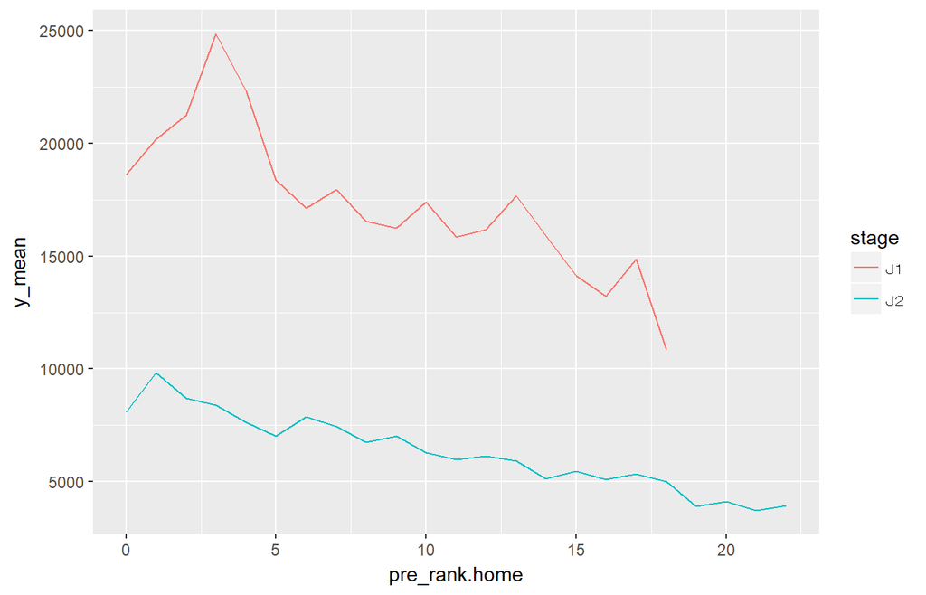

```r
train %>%
    dplyr::group_by(stage, pre_rank.home) %>%
    dplyr::summarise(y_mean = mean(y)) %>%
    dplyr::ungroup(.) %>%
    ggplot(., mapping=aes(x = pre_rank.home, y = y_mean)) + geom_line(mapping = aes(colour = stage))
```

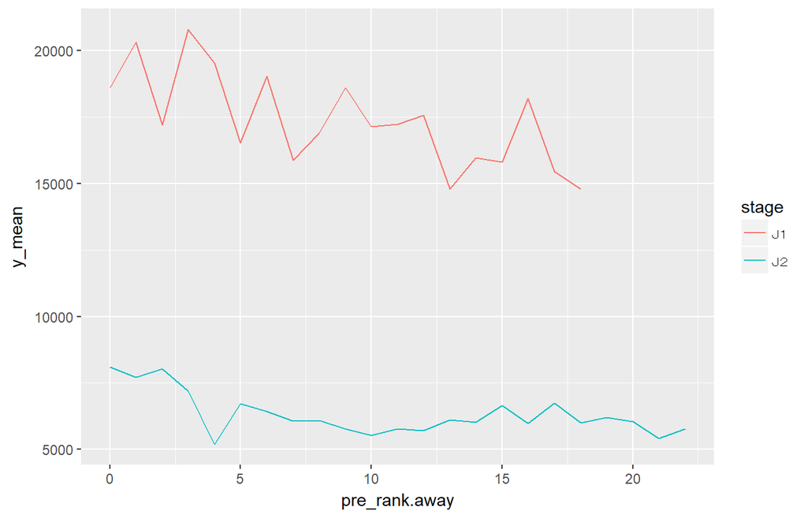

```r
train %>%
    dplyr::group_by(stage, pre_rank.away) %>%
    dplyr::summarise(y_mean = mean(y)) %>%
    dplyr::ungroup(.) %>%
    ggplot(., mapping=aes(x = pre_rank.away, y = y_mean)) + geom_line(mapping = aes(colour = stage))
```

## 5.2 対戦するチームの組合せによって集客が変わるのか？

年で若干異なる。傾向の有無までは判断できず。

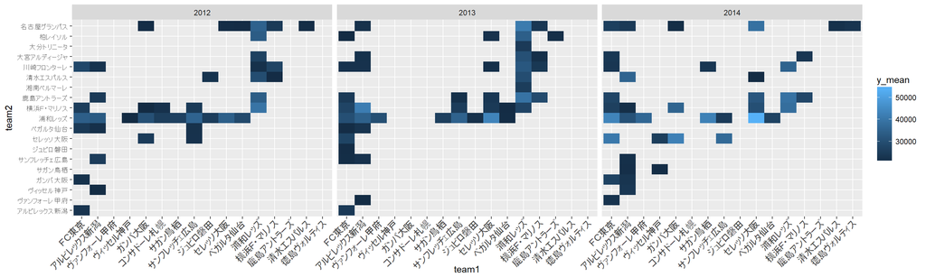

```r
train %>%
    dplyr::filter(stage == "Ｊ１") %>%
    dplyr::mutate(team1 = if_else(home_team < away_team, home_team, away_team),
                  team2 = if_else(home_team > away_team, home_team, away_team)) %>%
    dplyr::group_by(year, team1, team2) %>%
    dplyr::summarise(y_mean = mean(y)) %>%
    dplyr::ungroup(.) %>%
    dplyr::filter(y_mean > 20000) %>%
    ggplot(mapping=aes(x = team1, y = team2)) +
    geom_tile(mapping = aes(fill=y_mean)) +
    facet_grid(. ~ year) +
    theme(axis.text.x = element_text(angle = 45, hjust = 1))
```